# Risk Factor Analysis

## Outcome Variable

**Outcome Variable:** ever_wasted

## Predictor Variables

**Intervention Variable:** hhwealth_quart

**Adjustment Set:**

unadjusted

## Stratifying Variables

The analysis was stratified on these variable(s):

- agecat
- studyid
- country

## Data Summary

| agecat | studyid | country | hhwealth_quart | ever_wasted | n_cell | n |
| --- | --- | --- | --- | --- | --- | --- |
| 0-24 months | COHORTS | GUATEMALA | Wealth Q4 | 0 | 366 | 1263 |
| 0-24 months | COHORTS | GUATEMALA | Wealth Q4 | 1 | 110 | 1263 |
| 0-24 months | COHORTS | GUATEMALA | Wealth Q1 | 0 | 166 | 1263 |
| 0-24 months | COHORTS | GUATEMALA | Wealth Q1 | 1 | 78 | 1263 |
| 0-24 months | COHORTS | GUATEMALA | Wealth Q2 | 0 | 190 | 1263 |
| 0-24 months | COHORTS | GUATEMALA | Wealth Q2 | 1 | 68 | 1263 |
| 0-24 months | COHORTS | GUATEMALA | Wealth Q3 | 0 | 211 | 1263 |
| 0-24 months | COHORTS | GUATEMALA | Wealth Q3 | 1 | 74 | 1263 |
| 0-24 months | COHORTS | PHILIPPINES | Wealth Q4 | 0 | 531 | 3044 |
| 0-24 months | COHORTS | PHILIPPINES | Wealth Q4 | 1 | 309 | 3044 |
| 0-24 months | COHORTS | PHILIPPINES | Wealth Q1 | 0 | 372 | 3044 |
| 0-24 months | COHORTS | PHILIPPINES | Wealth Q1 | 1 | 309 | 3044 |
| 0-24 months | COHORTS | PHILIPPINES | Wealth Q2 | 0 | 330 | 3044 |
| 0-24 months | COHORTS | PHILIPPINES | Wealth Q2 | 1 | 210 | 3044 |
| 0-24 months | COHORTS | PHILIPPINES | Wealth Q3 | 0 | 582 | 3044 |
| 0-24 months | COHORTS | PHILIPPINES | Wealth Q3 | 1 | 401 | 3044 |
| 0-6 months | COHORTS | GUATEMALA | Wealth Q4 | 0 | 297 | 1015 |
| 0-6 months | COHORTS | GUATEMALA | Wealth Q4 | 1 | 72 | 1015 |
| 0-6 months | COHORTS | GUATEMALA | Wealth Q1 | 0 | 146 | 1015 |
| 0-6 months | COHORTS | GUATEMALA | Wealth Q1 | 1 | 50 | 1015 |
| 0-6 months | COHORTS | GUATEMALA | Wealth Q2 | 0 | 166 | 1015 |
| 0-6 months | COHORTS | GUATEMALA | Wealth Q2 | 1 | 36 | 1015 |
| 0-6 months | COHORTS | GUATEMALA | Wealth Q3 | 0 | 200 | 1015 |
| 0-6 months | COHORTS | GUATEMALA | Wealth Q3 | 1 | 48 | 1015 |
| 0-6 months | COHORTS | PHILIPPINES | Wealth Q4 | 0 | 627 | 3043 |
| 0-6 months | COHORTS | PHILIPPINES | Wealth Q4 | 1 | 213 | 3043 |
| 0-6 months | COHORTS | PHILIPPINES | Wealth Q1 | 0 | 504 | 3043 |
| 0-6 months | COHORTS | PHILIPPINES | Wealth Q1 | 1 | 176 | 3043 |
| 0-6 months | COHORTS | PHILIPPINES | Wealth Q2 | 0 | 424 | 3043 |
| 0-6 months | COHORTS | PHILIPPINES | Wealth Q2 | 1 | 116 | 3043 |
| 0-6 months | COHORTS | PHILIPPINES | Wealth Q3 | 0 | 771 | 3043 |
| 0-6 months | COHORTS | PHILIPPINES | Wealth Q3 | 1 | 212 | 3043 |
| 6-24 months | COHORTS | GUATEMALA | Wealth Q4 | 0 | 386 | 1154 |
| 6-24 months | COHORTS | GUATEMALA | Wealth Q4 | 1 | 47 | 1154 |
| 6-24 months | COHORTS | GUATEMALA | Wealth Q1 | 0 | 191 | 1154 |
| 6-24 months | COHORTS | GUATEMALA | Wealth Q1 | 1 | 34 | 1154 |
| 6-24 months | COHORTS | GUATEMALA | Wealth Q2 | 0 | 203 | 1154 |
| 6-24 months | COHORTS | GUATEMALA | Wealth Q2 | 1 | 38 | 1154 |
| 6-24 months | COHORTS | GUATEMALA | Wealth Q3 | 0 | 225 | 1154 |
| 6-24 months | COHORTS | GUATEMALA | Wealth Q3 | 1 | 30 | 1154 |
| 6-24 months | COHORTS | PHILIPPINES | Wealth Q4 | 0 | 626 | 2809 |
| 6-24 months | COHORTS | PHILIPPINES | Wealth Q4 | 1 | 145 | 2809 |
| 6-24 months | COHORTS | PHILIPPINES | Wealth Q1 | 0 | 406 | 2809 |
| 6-24 months | COHORTS | PHILIPPINES | Wealth Q1 | 1 | 200 | 2809 |
| 6-24 months | COHORTS | PHILIPPINES | Wealth Q2 | 0 | 368 | 2809 |
| 6-24 months | COHORTS | PHILIPPINES | Wealth Q2 | 1 | 136 | 2809 |
| 6-24 months | COHORTS | PHILIPPINES | Wealth Q3 | 0 | 660 | 2809 |
| 6-24 months | COHORTS | PHILIPPINES | Wealth Q3 | 1 | 268 | 2809 |

The following strata were considered:

- agecat: 0-24 months, studyid: COHORTS, country: GUATEMALA
- agecat: 0-24 months, studyid: COHORTS, country: PHILIPPINES
- agecat: 0-6 months, studyid: COHORTS, country: GUATEMALA
- agecat: 0-6 months, studyid: COHORTS, country: PHILIPPINES
- agecat: 6-24 months, studyid: COHORTS, country: GUATEMALA
- agecat: 6-24 months, studyid: COHORTS, country: PHILIPPINES

## Methods Detail

We’re interested in the causal parameters $E[Y_a]$ for all values of $a \in \mathcal{A}$. These parameters represent the mean outcome if, possibly contrary to fact, we intervened to set all units to have $A=a$. Under the randomization and positivity assumptions, these are identified by the statistical parameters $\psi_a=E_W[E_{Y|A,W}(Y|A=a,W)]$. In addition, we’re interested in the mean of $Y$, $E[Y]$ under no intervention (the observed mean). We will estimate these parameters by using SuperLearner to fit the relevant likelihood factors – $E_{Y|A,W}(Y|A=a,W)$ and $p(A=a|W)$, and then updating our likelihood fit using a joint TMLE.

For unadjusted analyses ($W=\{\}$), initial likelihoods were estimated using Lrnr_glm to estimate the simple $E(Y|A)$ and Lrnr_mean to estimate $p(A)$. For adjusted analyses, a small library containing Lrnr_glmnet, Lrnr_xgboost, and Lrnr_mean was used.

Having estimated these parameters, we will then use the delta method to estimate relative risks and attributable risks relative to a prespecified baseline level of $A$.

# Results Detail

## Results Plots

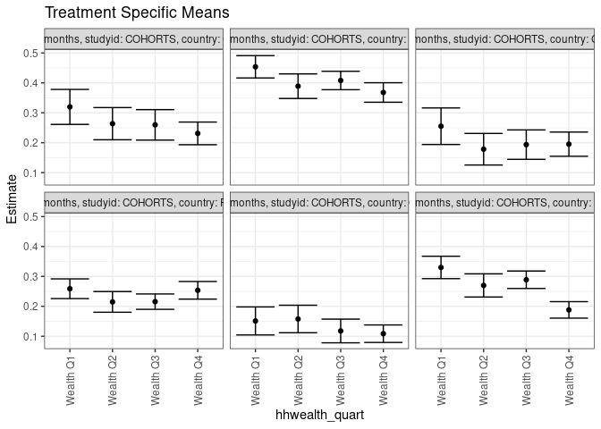

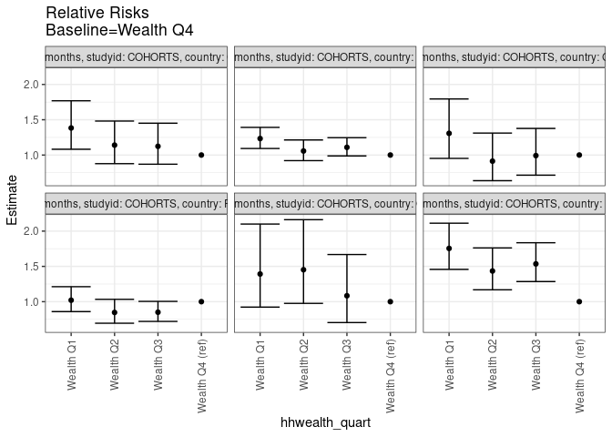

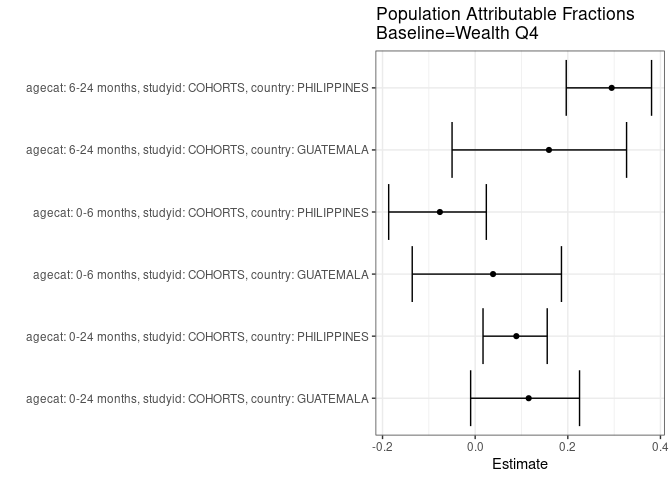

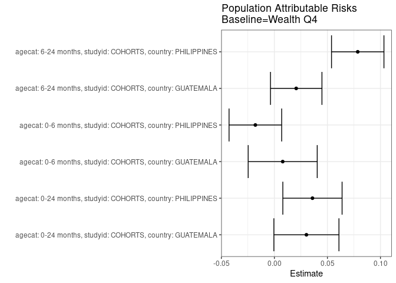

## Results Table

### Parameter: TSM

| agecat | studyid | country | intervention_level | baseline_level | estimate | ci_lower | ci_upper |
| --- | --- | --- | --- | --- | --- | --- | --- |
| 0-24 months | COHORTS | GUATEMALA | Wealth Q4 | NA | 0.2310924 | 0.1932092 | 0.2689756 |
| 0-24 months | COHORTS | GUATEMALA | Wealth Q1 | NA | 0.3196721 | 0.2611343 | 0.3782100 |
| 0-24 months | COHORTS | GUATEMALA | Wealth Q2 | NA | 0.2635659 | 0.2097858 | 0.3173460 |
| 0-24 months | COHORTS | GUATEMALA | Wealth Q3 | NA | 0.2596491 | 0.2087266 | 0.3105716 |
| 0-24 months | COHORTS | PHILIPPINES | Wealth Q4 | NA | 0.3678571 | 0.3352414 | 0.4004729 |
| 0-24 months | COHORTS | PHILIPPINES | Wealth Q1 | NA | 0.4537445 | 0.4163464 | 0.4911426 |
| 0-24 months | COHORTS | PHILIPPINES | Wealth Q2 | NA | 0.3888889 | 0.3477649 | 0.4300129 |
| 0-24 months | COHORTS | PHILIPPINES | Wealth Q3 | NA | 0.4079349 | 0.3772077 | 0.4386621 |
| 0-6 months | COHORTS | GUATEMALA | Wealth Q4 | NA | 0.1951220 | 0.1546674 | 0.2355765 |
| 0-6 months | COHORTS | GUATEMALA | Wealth Q1 | NA | 0.2551020 | 0.1940445 | 0.3161596 |
| 0-6 months | COHORTS | GUATEMALA | Wealth Q2 | NA | 0.1782178 | 0.1254170 | 0.2310186 |
| 0-6 months | COHORTS | GUATEMALA | Wealth Q3 | NA | 0.1935484 | 0.1443535 | 0.2427433 |
| 0-6 months | COHORTS | PHILIPPINES | Wealth Q4 | NA | 0.2535714 | 0.2241459 | 0.2829969 |
| 0-6 months | COHORTS | PHILIPPINES | Wealth Q1 | NA | 0.2588235 | 0.2258984 | 0.2917487 |
| 0-6 months | COHORTS | PHILIPPINES | Wealth Q2 | NA | 0.2148148 | 0.1801698 | 0.2494598 |
| 0-6 months | COHORTS | PHILIPPINES | Wealth Q3 | NA | 0.2156663 | 0.1899515 | 0.2413812 |
| 6-24 months | COHORTS | GUATEMALA | Wealth Q4 | NA | 0.1085450 | 0.0792329 | 0.1378571 |
| 6-24 months | COHORTS | GUATEMALA | Wealth Q1 | NA | 0.1511111 | 0.1042925 | 0.1979297 |
| 6-24 months | COHORTS | GUATEMALA | Wealth Q2 | NA | 0.1576763 | 0.1116453 | 0.2037074 |
| 6-24 months | COHORTS | GUATEMALA | Wealth Q3 | NA | 0.1176471 | 0.0780851 | 0.1572090 |
| 6-24 months | COHORTS | PHILIPPINES | Wealth Q4 | NA | 0.1880674 | 0.1604798 | 0.2156551 |
| 6-24 months | COHORTS | PHILIPPINES | Wealth Q1 | NA | 0.3300330 | 0.2925879 | 0.3674781 |
| 6-24 months | COHORTS | PHILIPPINES | Wealth Q2 | NA | 0.2698413 | 0.2310822 | 0.3086003 |
| 6-24 months | COHORTS | PHILIPPINES | Wealth Q3 | NA | 0.2887931 | 0.2596294 | 0.3179568 |

### Parameter: E(Y)

| agecat | studyid | country | intervention_level | baseline_level | estimate | ci_lower | ci_upper |
| --- | --- | --- | --- | --- | --- | --- | --- |
| 0-24 months | COHORTS | GUATEMALA | NA | NA | 0.2612827 | 0.2370438 | 0.2855216 |
| 0-24 months | COHORTS | PHILIPPINES | NA | NA | 0.4037451 | 0.3863123 | 0.4211779 |
| 0-6 months | COHORTS | GUATEMALA | NA | NA | 0.2029557 | 0.1782002 | 0.2277111 |
| 0-6 months | COHORTS | PHILIPPINES | NA | NA | 0.2356227 | 0.2205417 | 0.2507038 |
| 6-24 months | COHORTS | GUATEMALA | NA | NA | 0.1291161 | 0.1097606 | 0.1484716 |
| 6-24 months | COHORTS | PHILIPPINES | NA | NA | 0.2666429 | 0.2502871 | 0.2829988 |

### Parameter: RR

| agecat | studyid | country | intervention_level | baseline_level | estimate | ci_lower | ci_upper |
| --- | --- | --- | --- | --- | --- | --- | --- |
| 0-24 months | COHORTS | GUATEMALA | Wealth Q4 | Wealth Q4 | 1.0000000 | 1.0000000 | 1.000000 |
| 0-24 months | COHORTS | GUATEMALA | Wealth Q1 | Wealth Q4 | 1.3833085 | 1.0818823 | 1.768716 |
| 0-24 months | COHORTS | GUATEMALA | Wealth Q2 | Wealth Q4 | 1.1405215 | 0.8778702 | 1.481756 |
| 0-24 months | COHORTS | GUATEMALA | Wealth Q3 | Wealth Q4 | 1.1235726 | 0.8701438 | 1.450812 |
| 0-24 months | COHORTS | PHILIPPINES | Wealth Q4 | Wealth Q4 | 1.0000000 | 1.0000000 | 1.000000 |
| 0-24 months | COHORTS | PHILIPPINES | Wealth Q1 | Wealth Q4 | 1.2334802 | 1.0928441 | 1.392214 |
| 0-24 months | COHORTS | PHILIPPINES | Wealth Q2 | Wealth Q4 | 1.0571737 | 0.9209031 | 1.213609 |
| 0-24 months | COHORTS | PHILIPPINES | Wealth Q3 | Wealth Q4 | 1.1089492 | 0.9871561 | 1.245769 |
| 0-6 months | COHORTS | GUATEMALA | Wealth Q4 | Wealth Q4 | 1.0000000 | 1.0000000 | 1.000000 |
| 0-6 months | COHORTS | GUATEMALA | Wealth Q1 | Wealth Q4 | 1.3073980 | 0.9525446 | 1.794446 |
| 0-6 months | COHORTS | GUATEMALA | Wealth Q2 | Wealth Q4 | 0.9133663 | 0.6362087 | 1.311265 |
| 0-6 months | COHORTS | GUATEMALA | Wealth Q3 | Wealth Q4 | 0.9919355 | 0.7145473 | 1.377006 |
| 0-6 months | COHORTS | PHILIPPINES | Wealth Q4 | Wealth Q4 | 1.0000000 | 1.0000000 | 1.000000 |
| 0-6 months | COHORTS | PHILIPPINES | Wealth Q1 | Wealth Q4 | 1.0207125 | 0.8592567 | 1.212506 |
| 0-6 months | COHORTS | PHILIPPINES | Wealth Q2 | Wealth Q4 | 0.8471570 | 0.6945039 | 1.033364 |
| 0-6 months | COHORTS | PHILIPPINES | Wealth Q3 | Wealth Q4 | 0.8505151 | 0.7201501 | 1.004479 |
| 6-24 months | COHORTS | GUATEMALA | Wealth Q4 | Wealth Q4 | 1.0000000 | 1.0000000 | 1.000000 |
| 6-24 months | COHORTS | GUATEMALA | Wealth Q1 | Wealth Q4 | 1.3921513 | 0.9229806 | 2.099811 |
| 6-24 months | COHORTS | GUATEMALA | Wealth Q2 | Wealth Q4 | 1.4526353 | 0.9759917 | 2.162057 |
| 6-24 months | COHORTS | GUATEMALA | Wealth Q3 | Wealth Q4 | 1.0838548 | 0.7041520 | 1.668306 |
| 6-24 months | COHORTS | PHILIPPINES | Wealth Q4 | Wealth Q4 | 1.0000000 | 1.0000000 | 1.000000 |
| 6-24 months | COHORTS | PHILIPPINES | Wealth Q1 | Wealth Q4 | 1.7548651 | 1.4578230 | 2.112432 |
| 6-24 months | COHORTS | PHILIPPINES | Wealth Q2 | Wealth Q4 | 1.4348112 | 1.1685105 | 1.761801 |
| 6-24 months | COHORTS | PHILIPPINES | Wealth Q3 | Wealth Q4 | 1.5355826 | 1.2850789 | 1.834918 |

### Parameter: PAR

| agecat | studyid | country | intervention_level | baseline_level | estimate | ci_lower | ci_upper |
| --- | --- | --- | --- | --- | --- | --- | --- |
| 0-24 months | COHORTS | GUATEMALA | Wealth Q4 | NA | 0.0301902 | -0.0004840 | 0.0608645 |
| 0-24 months | COHORTS | PHILIPPINES | Wealth Q4 | NA | 0.0358879 | 0.0079491 | 0.0638268 |
| 0-6 months | COHORTS | GUATEMALA | Wealth Q4 | NA | 0.0078337 | -0.0247157 | 0.0403831 |
| 0-6 months | COHORTS | PHILIPPINES | Wealth Q4 | NA | -0.0179487 | -0.0427533 | 0.0068559 |
| 6-24 months | COHORTS | GUATEMALA | Wealth Q4 | NA | 0.0205711 | -0.0036995 | 0.0448417 |
| 6-24 months | COHORTS | PHILIPPINES | Wealth Q4 | NA | 0.0785755 | 0.0538612 | 0.1032898 |

### Parameter: PAF

| agecat | studyid | country | intervention_level | baseline_level | estimate | ci_lower | ci_upper |
| --- | --- | --- | --- | --- | --- | --- | --- |
| 0-24 months | COHORTS | GUATEMALA | Wealth Q4 | NA | 0.1155462 | -0.0097913 | 0.2253265 |
| 0-24 months | COHORTS | PHILIPPINES | Wealth Q4 | NA | 0.0888876 | 0.0169659 | 0.1555473 |
| 0-6 months | COHORTS | GUATEMALA | Wealth Q4 | NA | 0.0385982 | -0.1358896 | 0.1862823 |
| 0-6 months | COHORTS | PHILIPPINES | Wealth Q4 | NA | -0.0761755 | -0.1867271 | 0.0240775 |
| 6-24 months | COHORTS | GUATEMALA | Wealth Q4 | NA | 0.1593223 | -0.0498983 | 0.3268501 |
| 6-24 months | COHORTS | PHILIPPINES | Wealth Q4 | NA | 0.2946843 | 0.1966146 | 0.3807826 |